# Analysis and prediction of car accidents in Los Alngeles based on the collisions data from 2010 to 2019

Ali Behroozfar

## Abstract

In this project, Los Angeles traffic collision instances occurred from 2010 to 2019 are analyzed. In the relevant time series dataset, several variables including time/date of accidents, locations and some demographic information about the drivers are available. The main goals of this project are to analyze the effects of the variables on the number of collisions in different locations in LA and also predict the future trends/number of accidents in those areas. Since this project will provide information about the number of accidents in different days in different areas, its results can be used by all organizations which are responsible for the services required after a collison happens. Organizatins such as insurance companies, police department,traffic control companies, toll companies and health services will need such predictions for faster and more reliable services.

## Dataset overview

This dataset has 488384 instances of the car collisions in LA with 24 variables (the dataset is available on Kaggle). Some variables such as drivers’ license numbers, MO codes, Address and zip codes are not required for analysis purposes and are dropped from the dataset. The variables which might be useful are: Date Reported, Date Occurred, Time Occurred, Area ID, Area Name, Victim Age, collision location, Premise Code, Premise Description Reporting District, Crime Code, and Crime Code Description.

## Libraries which are required

In the begining the needed libraries are added.

```r
rm(list = ls())
library(data.table)
library(readr)
library(tidyverse)
```

```r
library(ggplot2)
library(lubridate)
library(dplyr)
library(imputeTS)
library(rmarkdown)
library(fpp2)
library(GGally)
library(gridExtra)
library(maps)
library(ggmap)
library(leaflet)
library(urca)
library(qdapRegex)
pacman::p_load(dplyr, fpp2, GGally, gridExtra)
```

## Processing the Data

The dataset is read and the features with their numbers of Null instances are listed below.

```r
collision_original<- read_csv("traffic-collision-data-from-2010-to-present.csv")
```

```r
map_int(collision_original,function(.x) sum(is.na(.x)))
```

```
##                         DR Number                     Date Reported
##                                 0                                 0
##                     Date Occurred                     Time Occurred
##                                 0                                 0
##                           Area ID                         Area Name
##                                 0                                 0
##                Reporting District                        Crime Code
##                                 0                                 0
##            Crime Code Description                          MO Codes
##                                 0                             85069
##                        Victim Age                        Victim Sex
##                             77907                              7196
##                    Victim Descent                      Premise Code
##                              7951                                25
##               Premise Description                           Address
##                                25                                 0
##                      Cross Street                          Location
##                             21945                                 0
##                         Zip Codes                     Census Tracts
##                               396                              6591
##               Precinct Boundaries                 LA Specific Plans
##                              3114                            308578
##                 Council Districts Neighborhood Councils (Certified)
##                              5770                             24381
```

Here, the useful features are selected:

```r
collision<-collision_original[,c("Date Reported","Date Occurred","Time Occurred","Area ID","Area Name","Reporting District","Crime Code","Crime Code Description","Victim Age","Victim Sex","Victim Descent","Premise Code","Premise Description","Location","Census Tracts")]
```

The selected features and the number of null instances are listed below:

```r
map_int(collision,function(.x) sum(is.na(.x)))
```

```
##          Date Reported          Date Occurred          Time Occurred
##                      0                      0                      0
##                Area ID              Area Name     Reporting District
##                      0                      0                      0
##             Crime Code Crime Code Description             Victim Age
##                      0                      0                  77907
##             Victim Sex         Victim Descent           Premise Code
##                   7196                   7951                     25
##    Premise Description               Location          Census Tracts
##                     25                      0                   6591
```

```r
is.unsorted(collision)
```

```
## [1] NA
```

```r
collision<- collision[seq(dim(collision)[1],1),]
```

## Missing value imputation for Null ages in the dataset

To make some useful visuallizations specially for Age variable, we need to impute the Null values. The data set is a time series so we cannot easily drop the Null values. Imputation is done to impute the age variables in this data set. So different functions of Kalman method and moving average were tested to choose the closest distribution of ages after imputation to the original age distribution.

```r
collision$age_kalman<-na.kalman(collision$`Victim Age`)
collision$age_ma_exp<-na.ma(collision$`Victim Age`,k=4,weighting = "exponential")
```

```r
collision$age_ma_sim<-na.ma(collision$`Victim Age`,weighting = "simple")
collision$age_ma_lin<-na.ma(collision$`Victim Age`,weighting = "linear")
collision$age_mean<-na.mean(collision$`Victim Age`)
```

The different age distributions after imputation using KAlman are shown below. The first graph show the age distribution in the original dataset.The second one is imputation by Kalman smoothinh (which is not good).Imputation by weighted moving average is in good agreement with the oroginal age distribuion.

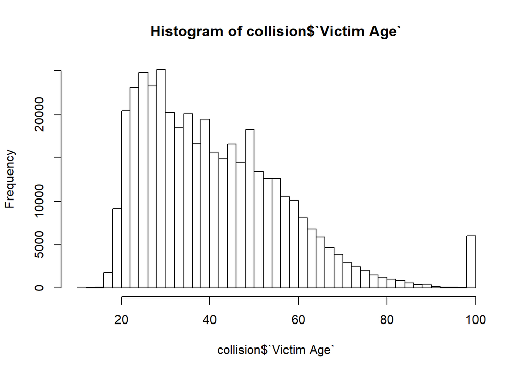

```r
hist(collision$`Victim Age`,breaks = 50)
```

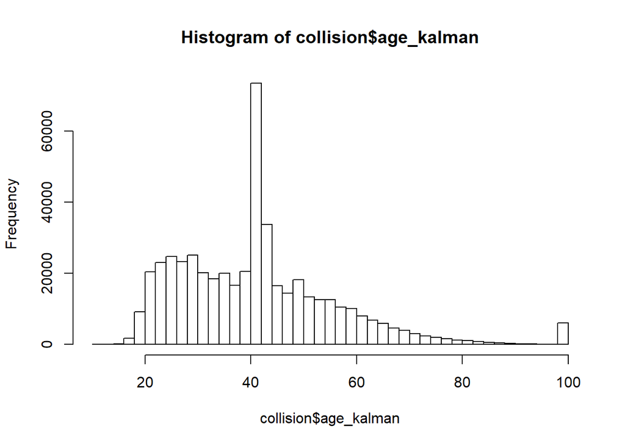

```r
hist(collision$age_kalman,breaks = 50)
```

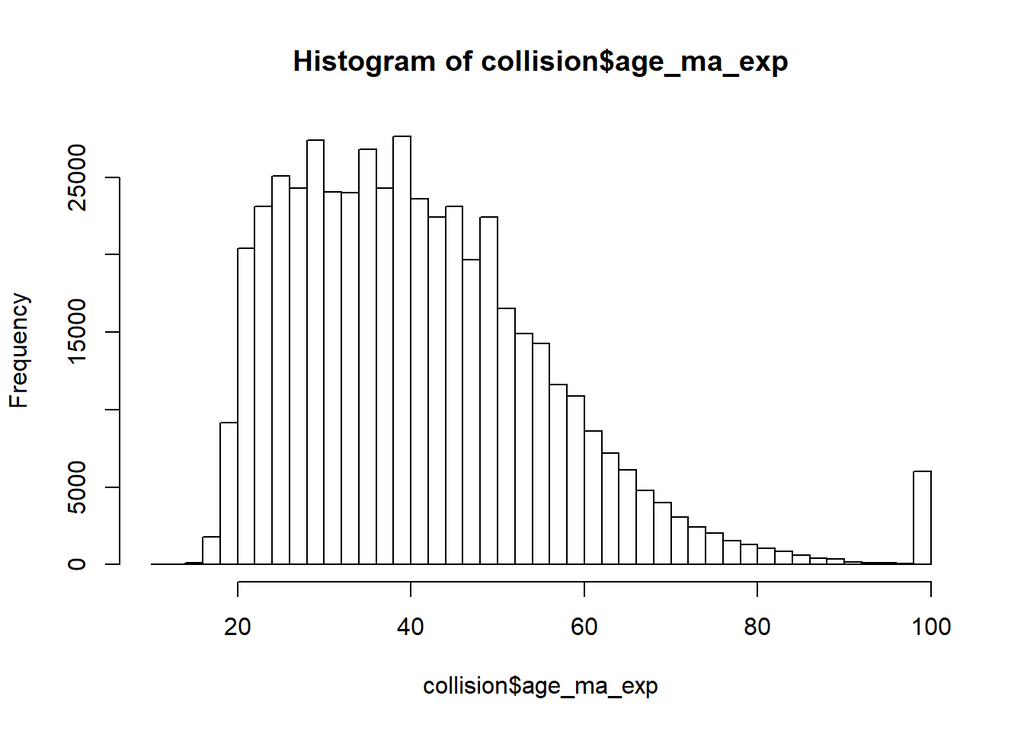

```r
hist(collision$age_ma_exp,breaks = 50)
```

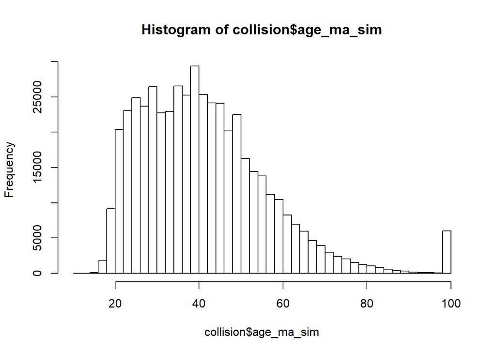

```r
hist(collision$age_ma_sim,breaks = 50)
```

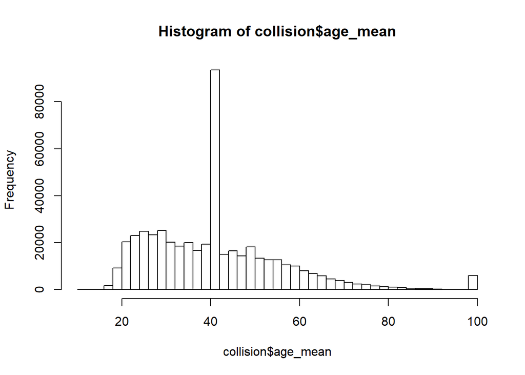

```r
hist(collision$age_mean,breaks = 50)
```

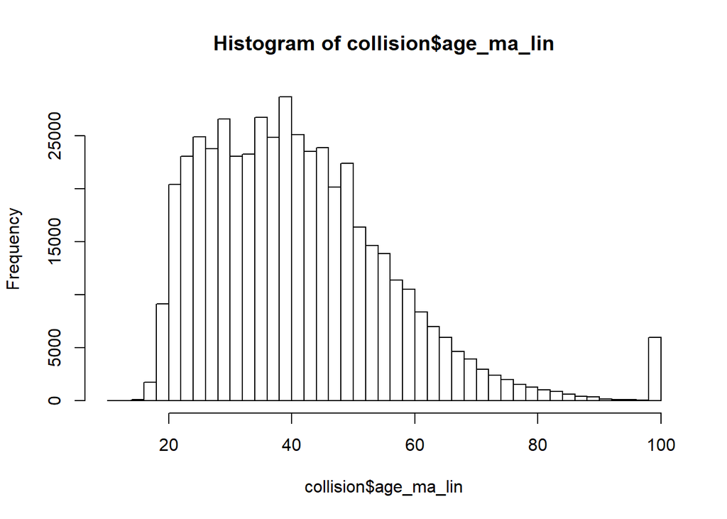

```r
hist(collision$age_ma_lin,breaks = 50)
```

```r
mean(collision$age_kalman)
```

```
## [1] 41.51249
```

```r
mean(collision$age_ma_exp)
```

```
## [1] 41.50949
```

```r
mean(collision$age_ma_sim)
```

```
## [1] 41.50772
```

```r
mean(collision$age_mean)
```

```
## [1] 41.5056
```

```r
mean(collision$age_ma_lin)
```

```
## [1] 41.5086
```

```r
collision$age<-collision$age_ma_exp
```

```r
mean(collision$age)
```

```
## [1] 41.50949
```

```r
map_int(collision,function(.x)sum(is.na(.x)))
```

```
##          Date Reported          Date Occurred          Time Occurred
##                      0                      0                      0
##                Area ID              Area Name     Reporting District
##                      0                      0                      0
##             Crime Code Crime Code Description             Victim Age
##                      0                      0                  77907
##             Victim Sex         Victim Descent           Premise Code
##                   7196                   7951                     25
##    Premise Description               Location          Census Tracts
##                     25                      0                   6591
##             age_kalman             age_ma_exp             age_ma_sim
##                      0                      0                      0
##             age_ma_lin               age_mean                    age
##                      0                      0                      0
```

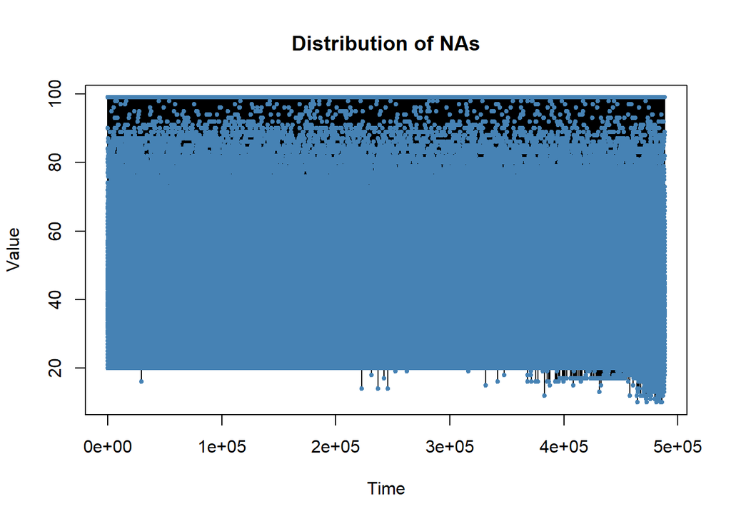

```r
plotNA.distribution(collision$age)
```

people in CA can get the drivers lisence at the age of 16 to 18 years old (driving with a person above 25 yo in the car) and at 18 and above (driving alone). Also it seems in some cases with low ages, the ages were rounded up to 20 (the dataset is censored). It has not happened in the recent years. In addition, there are many cases with the age of 99. Again it seems for a particular age rane (probably 80+), the ages were rounded up to 99. so it is better to analyze the age variable based on the age bins (like: <40, 40-60, 60-80 , >80) It should be noted that there are few report on accidents with ages below 16. Lets take a look at the outliers:

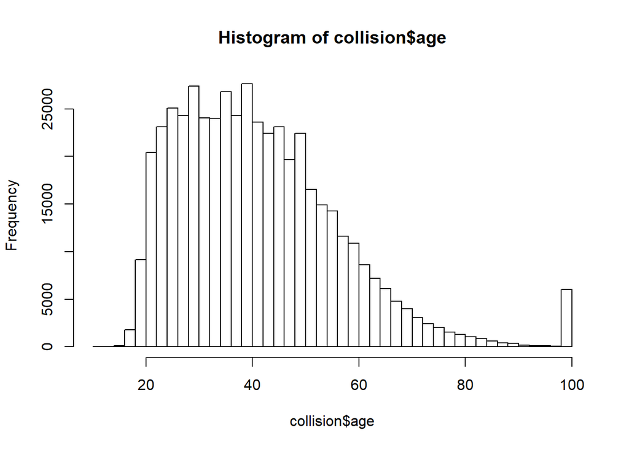

```r
hist(collision$age,breaks = 50)
```

```r
nrow(collision[collision$age==99,])
```

```
## [1] 6003
```

```r
nrow(collision[collision$age<16,])
```

```
## [1] 99
```

6003 out of 488384 cases in the dataset were rounded up to 99 99 out of 488384 cases in the dataset report ages below 16 (these ages should be wrong).

```r
collision[collision$age<16,]
```

| Date Reported | Date Occurred | Time Occurred | Area ID | Area Name | Reporting District | Crime Code | Crime Code Description | Victim Age | Victim Sex | Victim Descent | Premise Code | Premise Description | Location | Census Tracts | age_kalman | age_ma_exp | age_ma_sim | age_ma_lin | age_mean | age |
| --- | --- | --- | --- | --- | --- | --- | --- | --- | --- | --- | --- | --- | --- | --- | --- | --- | --- | --- | --- | --- |
| 2014-11-24 | 2014-11-24 | 1625 | 04 | Hollenbeck | 0441 | 997 | TRAFFIC COLLISION | 14 | M | O | 101 | STREET | {'latitude': '34.059', 'longitude': '-118.2164', 'human_address': '{"address": "", "city": "", "state": "", "zip": ""}'} | 511 | 14 | 14 | 14 | 14 | 14 | 14 |
| 2015-03-12 | 2015-03-11 | 2115 | 12 | 77th Street | 1268 | 997 | TRAFFIC COLLISION | 14 | M | W | 101 | STREET | {'latitude': '33.9628', 'longitude': '-118.2739', 'human_address': '{"address": "", "city": "", "state": "", "zip": ""}'} | 795 | 14 | 14 | 14 | 14 | 14 | 14 |
| 2015-05-08 | 2015-05-08 | 0530 | 03 | Southwest | 0377 | 997 | TRAFFIC COLLISION | 14 | NA | NA | 101 | STREET | {'latitude': '34.0182', 'longitude': '-118.3002', 'human_address': '{"address": "", "city": "", "state": "", "zip": ""}'} | 690 | 14 | 14 | 14 | 14 | 14 | 14 |
| 2016-11-29 | 2016-11-29 | 1525 | 03 | Southwest | 0319 | 997 | TRAFFIC COLLISION | 15 | X | X | 101 | STREET | {'latitude': '34.0277', 'longitude': '-118.276', 'human_address': '{"address": "", "city": "", "state": "", "zip": ""}'} | 701 | 15 | 15 | 15 | 15 | 15 | 15 |
| 2017-10-23 | 2017-10-22 | 1815 | 03 | Southwest | 0374 | 997 | TRAFFIC COLLISION | 12 | M | B | 101 | STREET | {'latitude': '34.0108', 'longitude': '-118.3204', 'human_address': '{"address": "", "city": "", "state": "", "zip": ""}'} | 747 | 12 | 12 | 12 | 12 | 12 | 12 |
| 2017-11-20 | 2017-11-19 | 1740 | 13 | Newton | 1343 | 997 | TRAFFIC COLLISION | 15 | F | B | 101 | STREET | {'latitude': '34.0092', 'longitude': '-118.2565', 'human_address': '{"address": "", "city": "", "state": "", "zip": ""}'} | 712 | 15 | 15 | 15 | 15 | 15 | 15 |
| 2018-04-01 | 2018-04-01 | 1140 | 21 | Topanga | 2177 | 997 | TRAFFIC COLLISION | 15 | M | H | 101 | STREET | {'latitude': '34.1733', 'longitude': '-118.5882', 'human_address': '{"address": "", "city": "", "state": "", "zip": ""}'} | 305 | 15 | 15 | 15 | 15 | 15 | 15 |
| 2018-08-24 | 2018-08-24 | 1940 | 13 | Newton | 1345 | 997 | TRAFFIC COLLISION | 13 | M | H | 101 | STREET | {'latitude': '34.0093', 'longitude': '-118.2565', 'human_address': '{"address": "", "city": "", "state": "", "zip": ""}'} | 712 | 13 | 13 | 13 | 13 | 13 | 13 |
| 2018-09-03 | 2018-09-03 | 1505 | 16 | Foothill | 1642 | 997 | TRAFFIC COLLISION | 15 | M | H | 101 | STREET | {'latitude': '34.257', 'longitude': '-118.4201', 'human_address': '{"address": "", "city": "", "state": "", "zip": ""}'} | 30 | 15 | 15 | 15 | 15 | 15 | 15 |
| 2019-02-12 | 2019-02-12 | 0800 | 17 | Devonshire | 1749 | 997 | TRAFFIC COLLISION | 12 | F | H | 101 | STREET | {'latitude': '34.2637', 'longitude': '-118.4806', 'human_address': '{"address": "", "city": "", "state": "", "zip": ""}'} | 75 | 12 | 12 | 12 | 12 | 12 | 12 |

[output cut: 89 more lines]

Knowing this fact, I made 4 different bins and did analysis based on those bins. All ages below 40 were put in the first bin. In other sections of this report the analysis on age in different areas can be seen.

```r
collision$`Victim Sex`%>%table()
```

```
## .
##      F      H      M      N      X
## 184950    133 284766     11  11328
```

```r
collision$`Victim Sex`%>%is.na()%>%sum()
```

```
## [1] 7196
```

## Preparing the dataset for timeseries alanysis

The timestamp colomn of the dataset should be devided to days, months and years for further analysis. Specially “Day” variable is important for us for predicting purposes.

```r
collision$Date<- as.POSIXct(collision$`Date Occurred`,format="%m/%d/%Y")
collision$Month <- month(collision$Date, label=TRUE)
collision$Weekday <-wday(collision$Date, label=TRUE)
collision$Year <- year(collision$Date)
collision$Day <-day(collision$Date)
```

Names of the features are being changes to simpler ones:

```r
names(collision)<-c("date_reported","date_occured","time_occured","area_id","area_name","district","crime_code","crime_desciption","victim_age","sex","descent","premise","premise_description","Location","Census_Tracts","ageage_kalman","age_ma_exp","age_ma_sim","age_mean","age_ma_lin","age","date","month","weekday","year","day")
names(collision)
```

```
##  [1] "date_reported"       "date_occured"        "time_occured"
##  [4] "area_id"             "area_name"           "district"
##  [7] "crime_code"          "crime_desciption"    "victim_age"
## [10] "sex"                 "descent"             "premise"
## [13] "premise_description" "Location"            "Census_Tracts"
## [16] "ageage_kalman"       "age_ma_exp"          "age_ma_sim"
## [19] "age_mean"            "age_ma_lin"          "age"
## [22] "date"                "month"               "weekday"
## [25] "year"                "day"
```

Also time of the accidents is important for our analysis. The visualizations on time variable is very informative for preventive actions.

```r
collision$time <- as.POSIXct(collision$time_occured,format="%H%M")
collision$time <- hour(collision$time)
names(collision)
```

```
##  [1] "date_reported"       "date_occured"        "time_occured"
##  [4] "area_id"             "area_name"           "district"
##  [7] "crime_code"          "crime_desciption"    "victim_age"
## [10] "sex"                 "descent"             "premise"
## [13] "premise_description" "Location"            "Census_Tracts"
## [16] "ageage_kalman"       "age_ma_exp"          "age_ma_sim"
## [19] "age_mean"            "age_ma_lin"          "age"
## [22] "date"                "month"               "weekday"
## [25] "year"                "day"                 "time"
```

The pie chart below shows different areas of LA with their corresponding total number of acidents in the ascending order (clockwise). According to this chart, “77th Street” which is on the south of LA downtown had the highest number of collisions.

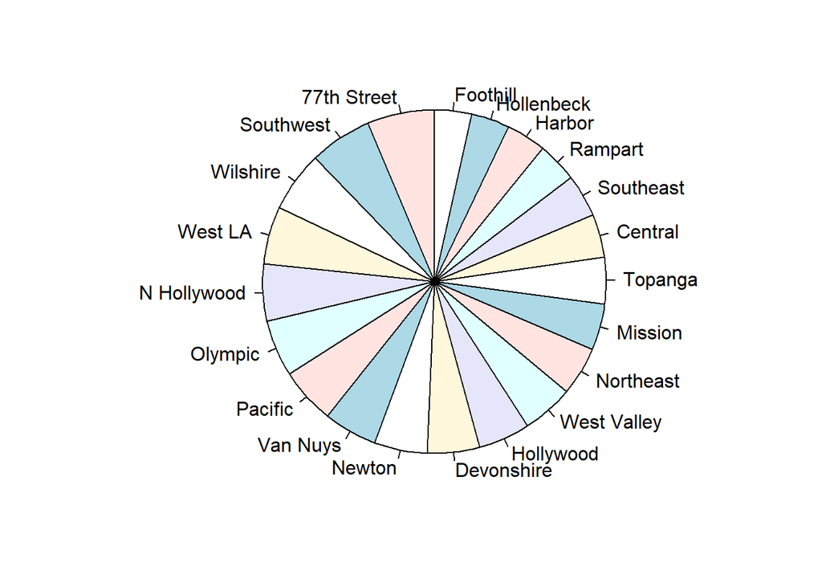

```r
xxx<-as.data.table(table(collision$area_name))
xxx<-arrange(xxx,N)
pie(xxx$N,clockwise = TRUE,
    labels=paste(xxx$V1), radius=1 )
```

## Heatmaps showing distribution of collisions in different areas of LA through days of the week

In the heatmaps showed below, distribution of the number of car collisions through days of the week is shown for different areas of LA. As shown below, on the weekdays, most accidents happen during business hours specially at the time that people are going back to home in afternoon. However, on weekends, we see high number of accidents ate at night in the areas near Downtown LA and areas with more resturants and bars (For example, there is a high number of collisions in Hollywood area in Saturday and Sunday early morning (1-3 am)).

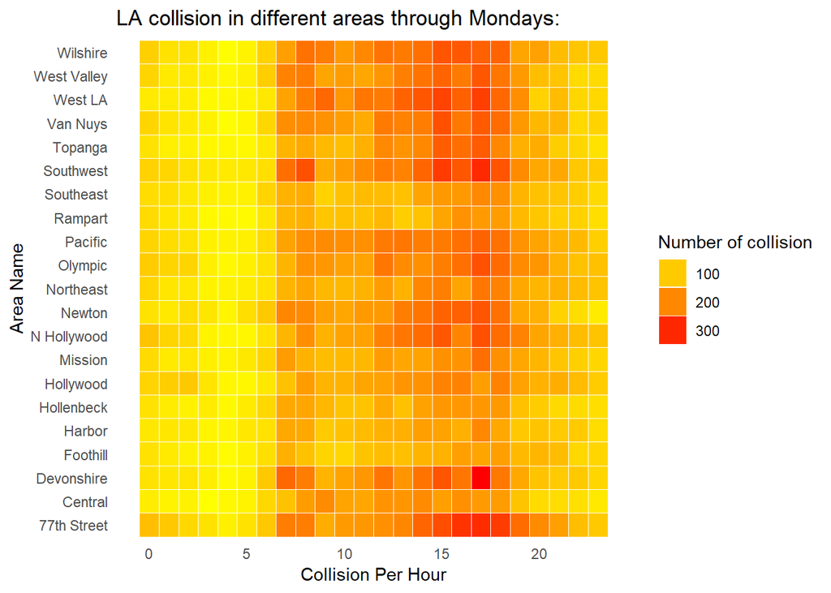

```r
hourly_wise_count<-collision %>% group_by(time,area_name,weekday) %>% count()
col1 = "#d8e1cf"
col2 = "#438484"


ggplot(hourly_wise_count[hourly_wise_count$weekday=='Mon',], aes(time,area_name)) + geom_tile(aes(fill = n),colour = "white") +
  scale_fill_gradient(low = "yellow", high = "red") +
  guides(fill=guide_legend(title="Number of collision")) +
  theme_bw() + theme_minimal() +
  labs(title = "LA collision in different areas through Mondays: ",
       x = "Collision Per Hour", y = "Area Name") +
  theme(panel.grid.major = element_blank(), panel.grid.minor = element_blank())
```

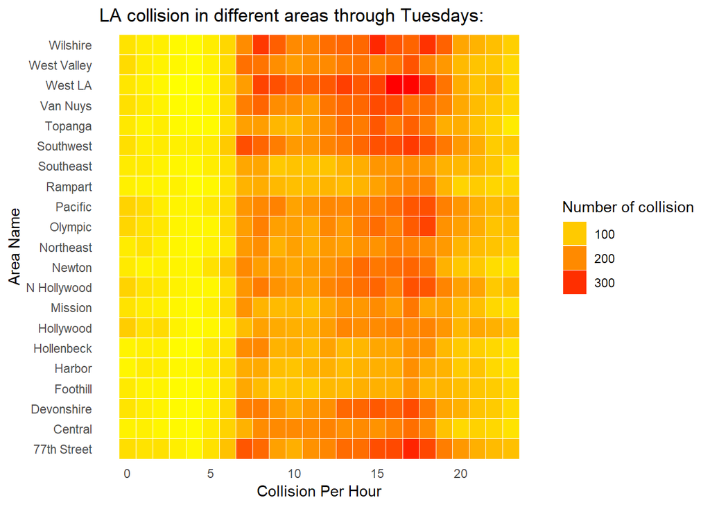

```r
ggplot(hourly_wise_count[hourly_wise_count$weekday=='Tue',], aes(time,area_name)) + geom_tile(aes(fill = n),colour = "white") +
  scale_fill_gradient(low = "yellow", high = "red") +
  guides(fill=guide_legend(title="Number of collision")) +
  theme_bw() + theme_minimal() +
  labs(title = "LA collision in different areas through Tuesdays: ",
       x = "Collision Per Hour", y = "Area Name") +
  theme(panel.grid.major = element_blank(), panel.grid.minor = element_blank())
```

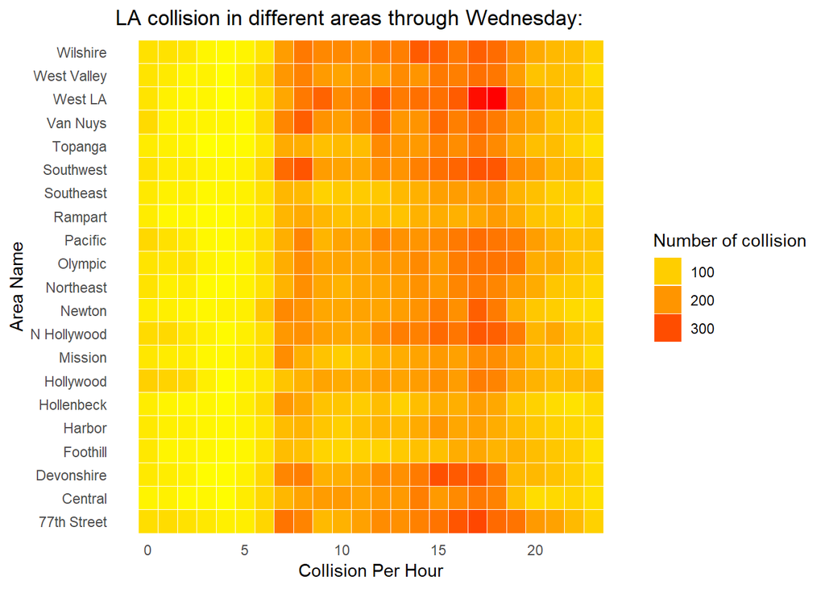

```r
ggplot(hourly_wise_count[hourly_wise_count$weekday=='Wed',], aes(time,area_name)) + geom_tile(aes(fill = n),colour = "white") +
  scale_fill_gradient(low = "yellow", high = "red") +
  guides(fill=guide_legend(title="Number of collision")) +
  theme_bw() + theme_minimal() +
  labs(title = "LA collision in different areas through Wednesday: ",
       x = "Collision Per Hour", y = "Area Name") +
  theme(panel.grid.major = element_blank(), panel.grid.minor = element_blank())
```

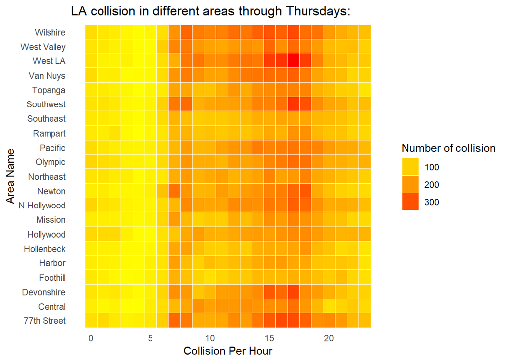

```r
ggplot(hourly_wise_count[hourly_wise_count$weekday=='Thu',], aes(time,area_name)) + geom_tile(aes(fill = n),colour = "white") +
  scale_fill_gradient(low = "yellow", high = "red") +
  guides(fill=guide_legend(title="Number of collision")) +
  theme_bw() + theme_minimal() +
  labs(title = "LA collision in different areas through Thursdays: ",
       x = "Collision Per Hour", y = "Area Name") +
  theme(panel.grid.major = element_blank(), panel.grid.minor = element_blank())
```

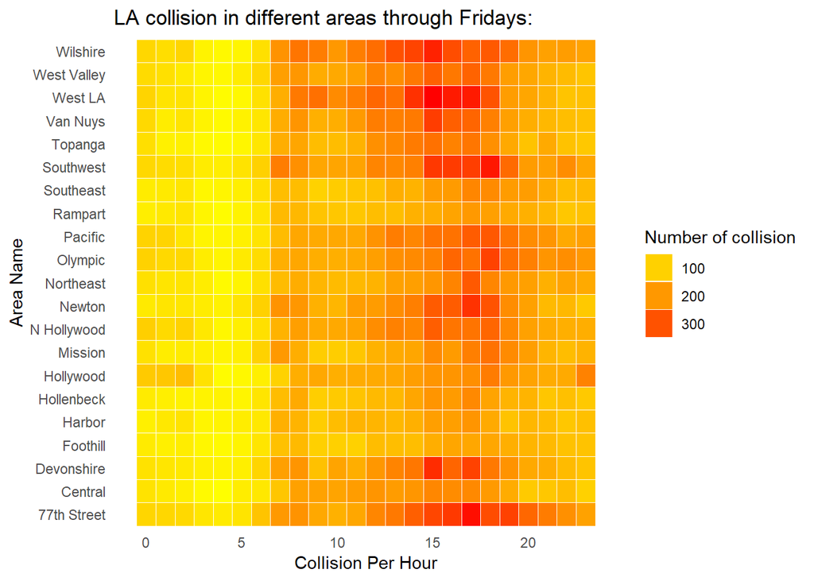

```r
ggplot(hourly_wise_count[hourly_wise_count$weekday=='Fri',], aes(time,area_name)) + geom_tile(aes(fill = n),colour = "white") +
  scale_fill_gradient(low = "yellow", high = "red") +
  guides(fill=guide_legend(title="Number of collision")) +
  theme_bw() + theme_minimal() +
  labs(title = "LA collision in different areas through Fridays: ",
       x = "Collision Per Hour", y = "Area Name") +
  theme(panel.grid.major = element_blank(), panel.grid.minor = element_blank())
```

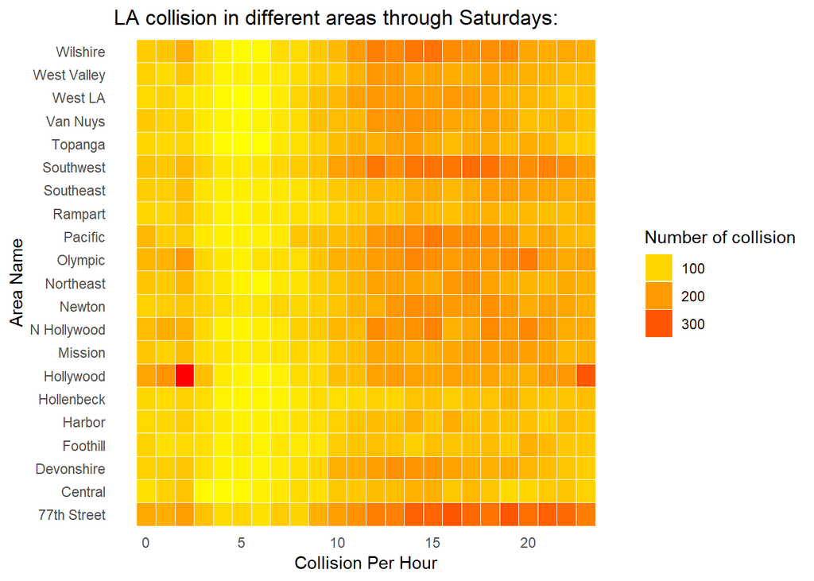

```r
ggplot(hourly_wise_count[hourly_wise_count$weekday=='Sat',], aes(time,area_name)) + geom_tile(aes(fill = n),colour = "white") +
  scale_fill_gradient(low = "yellow", high = "red") +
  guides(fill=guide_legend(title="Number of collision")) +
  theme_bw() + theme_minimal() +
  labs(title = "LA collision in different areas through Saturdays: ",
       x = "Collision Per Hour", y = "Area Name") +
  theme(panel.grid.major = element_blank(), panel.grid.minor = element_blank())
```

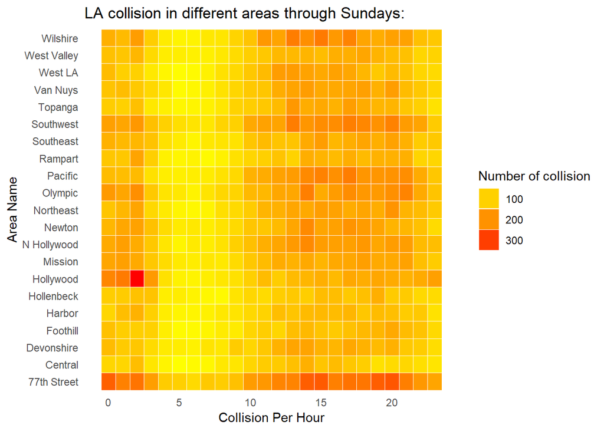

```r
ggplot(hourly_wise_count[hourly_wise_count$weekday=='Sun',], aes(time,area_name)) + geom_tile(aes(fill = n),colour = "white") +
  scale_fill_gradient(low = "yellow", high = "red") +
  guides(fill=guide_legend(title="Number of collision")) +
  theme_bw() + theme_minimal() +
  labs(title = "LA collision in different areas through Sundays: ",
       x = "Collision Per Hour", y = "Area Name") +
  theme(panel.grid.major = element_blank(), panel.grid.minor = element_blank())
```

```r
collision$age_range[collision$age_ma_exp<40]<-20
collision$age_range[(collision$age_ma_exp>=40)&(collision$age_ma_exp<60)]<-40
collision$age_range[(collision$age_ma_exp>=60)&(collision$age_ma_exp<80)]<-60
collision$age_range[collision$age_ma_exp>=80]<-80

collision$age_range<-as.factor(collision$age_range)
collision %>% group_by(age_range)%>% count()
```

| age_range | n |
| --- | --- |
| 20 | 246592 |
| 40 | 185810 |
| 60 | 45635 |
| 80 | 10347 |

## Effects of driver’s age on the distribution of the accidents counts in different days of the wek

It is expected to have different distributions for number of accidents hapened by differnet ages. In this section we see the effet of this variable on the accident count distribuiton. For younger drivers (age<40) we see high number of accidents at weekend nights. However sum of the acccident occured by this age group is not noticeable at weekdays nights. it seems number of drunk drivers is more in this age group causing these accidents at weekend nights (no surprise). Also in the weekdays mornings and afternoons there are peaks in the collison dstribution. In the old drivers group, there is only a peak in the afternoon in all days of the week. This information determines the main types of the services (and the age targets recienving the services)in differet times and days.

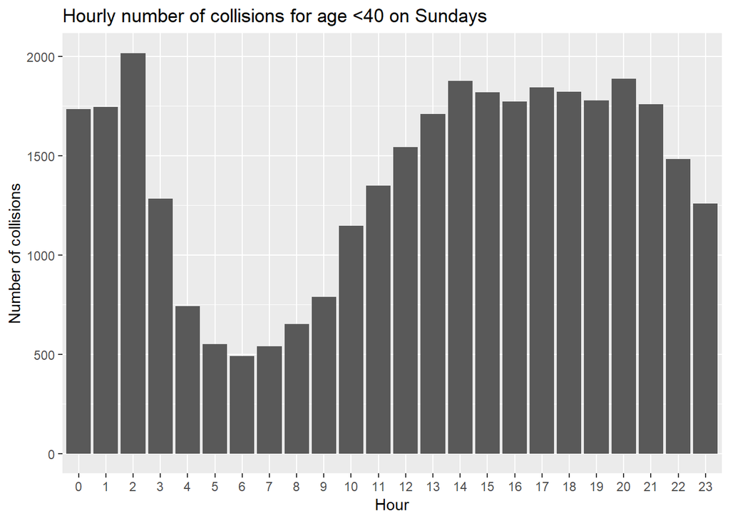

```r
collision_sun<-collision[collision$weekday=='Sun',]
collision_Tue<-collision[collision$weekday=='Tue',]


hourly_age20_count<-collision_sun[collision_sun$age_range==20,] %>% group_by(time) %>% count()
ggplot(data=hourly_age20_count,aes(x=as.factor(time),y=n))+
  labs(x='Hour',y='Number of collisions',title = 'Hourly number of collisions for age <40 on Sundays')+
  geom_bar(stat = "identity")
```

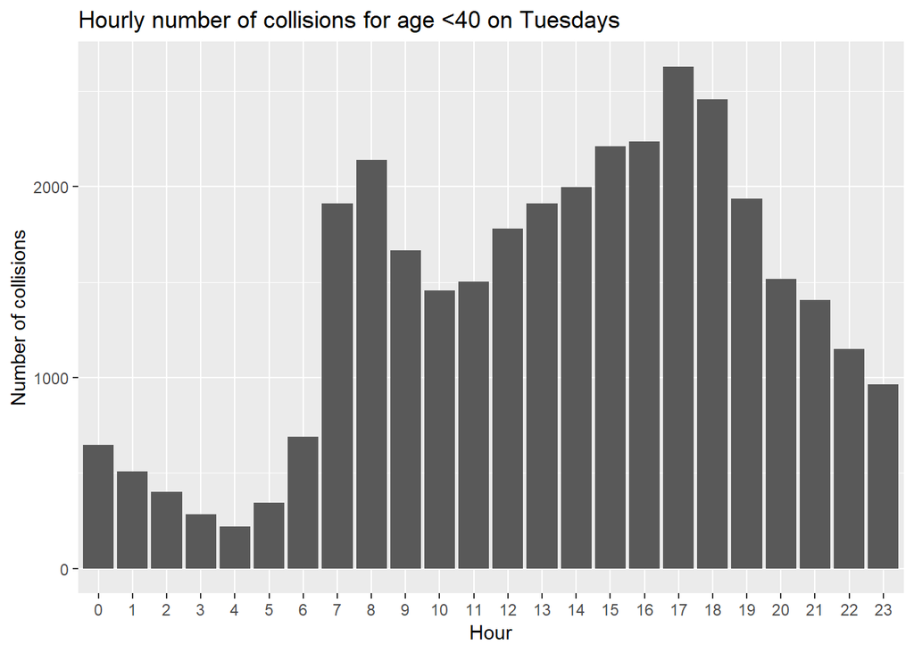

```r
hourly_age20_count<-collision_Tue[collision_Tue$age_range==20,] %>% group_by(time) %>% count()
ggplot(data=hourly_age20_count,aes(x=as.factor(time),y=n))+
  labs(x='Hour',y='Number of collisions',title = 'Hourly number of collisions for age <40 on Tuesdays')+
  geom_bar(stat = "identity")
```

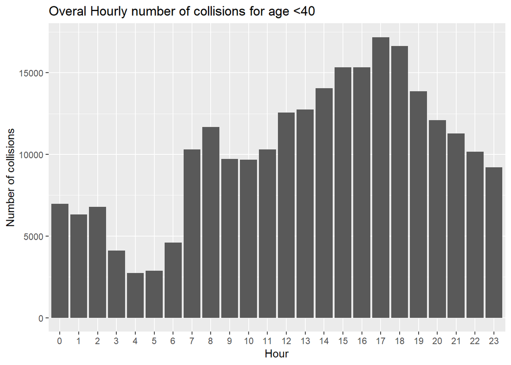

```r
hourly_age20_count<-collision[collision$age_range==20,] %>% group_by(time) %>% count()
ggplot(data=hourly_age20_count,aes(x=as.factor(time),y=n))+
  labs(x='Hour',y='Number of collisions',title = 'Overal Hourly number of collisions for age <40')+
  geom_bar(stat = "identity")
```

ages between 40 and 60

[figure not shown]

```r
collision_sun<-collision[collision$weekday=='Sun',]
collision_Tue<-collision[collision$weekday=='Tue',]


hourly_age40_count<-collision_sun[collision_sun$age_range==40,] %>% group_by(time) %>% count()
ggplot(data=hourly_age20_count,aes(x=as.factor(time),y=n))+
  labs(x='Hour',y='Number of collisions',title = 'Hourly number of collisions for age between 40 and 60 on Sundays')+
  geom_bar(stat = "identity")
```

[figure not shown]

```r
hourly_age40_count<-collision_Tue[collision_Tue$age_range==40,] %>% group_by(time) %>% count()
ggplot(data=hourly_age20_count,aes(x=as.factor(time),y=n))+
  labs(x='Hour',y='Number of collisions',title = 'Hourly number of collisions for age between 40 and 60 on Tuesdays')+
  geom_bar(stat = "identity")
```

[figure not shown]

```r
hourly_age40_count<-collision[collision$age_range==40,] %>% group_by(time) %>% count()
ggplot(data=hourly_age20_count,aes(x=as.factor(time),y=n))+
  labs(x='Hour',y='Number of collisions',title = 'Overal Hourly number of collisions for age between 40 and 60')+
  geom_bar(stat = "identity")
```

ages between 60 and 80

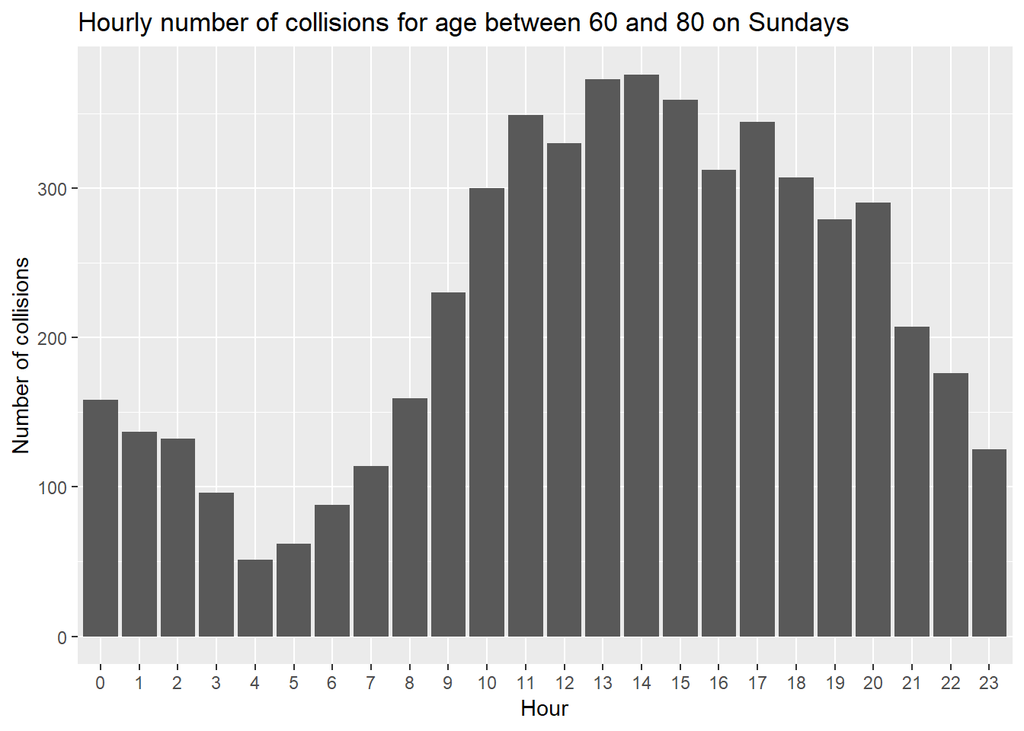

```r
collision_sun<-collision[collision$weekday=='Sun',]
collision_Tue<-collision[collision$weekday=='Tue',]


hourly_age60_count<-collision_sun[collision_sun$age_range==60,] %>% group_by(time) %>% count()
ggplot(data=hourly_age60_count,aes(x=as.factor(time),y=n))+
  labs(x='Hour',y='Number of collisions',title = 'Hourly number of collisions for age between 60 and 80 on Sundays')+
  geom_bar(stat = "identity")
```

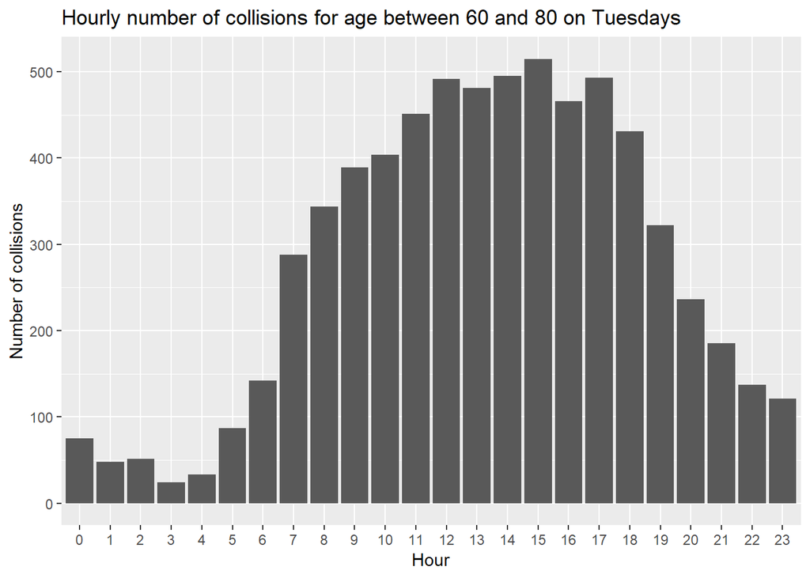

```r
hourly_age60_count<-collision_Tue[collision_Tue$age_range==60,] %>% group_by(time) %>% count()
ggplot(data=hourly_age60_count,aes(x=as.factor(time),y=n))+
  labs(x='Hour',y='Number of collisions',title = 'Hourly number of collisions for age between 60 and 80 on Tuesdays')+
  geom_bar(stat = "identity")
```

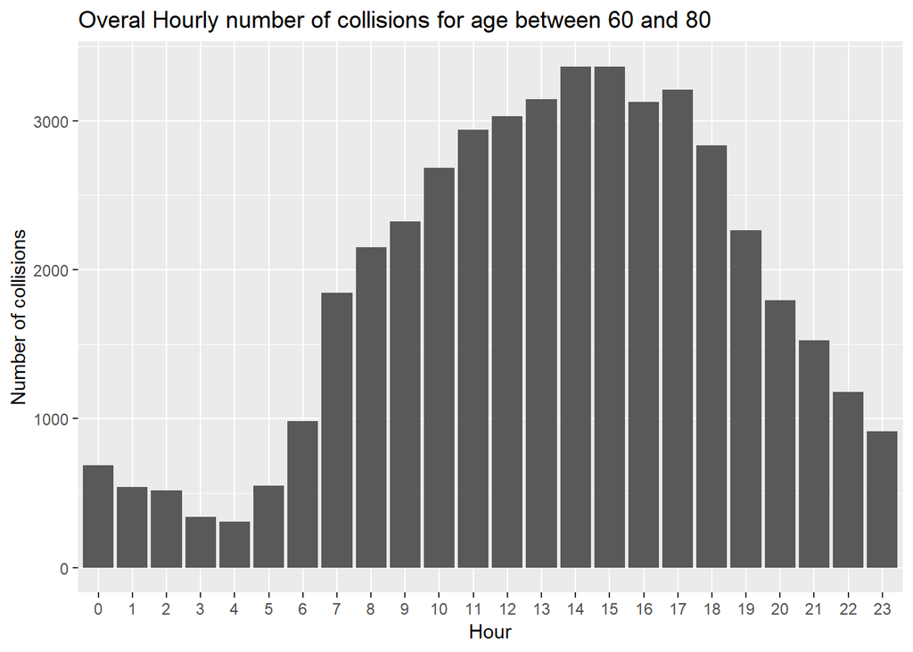

```r
hourly_age60_count<-collision[collision$age_range==60,] %>% group_by(time) %>% count()
ggplot(data=hourly_age60_count,aes(x=as.factor(time),y=n))+
  labs(x='Hour',y='Number of collisions',title = 'Overal Hourly number of collisions for age between 60 and 80')+
  geom_bar(stat = "identity")
```

In the heatmaps shown below, distribution of the accidents through days of the week caused by different age groups are shown.

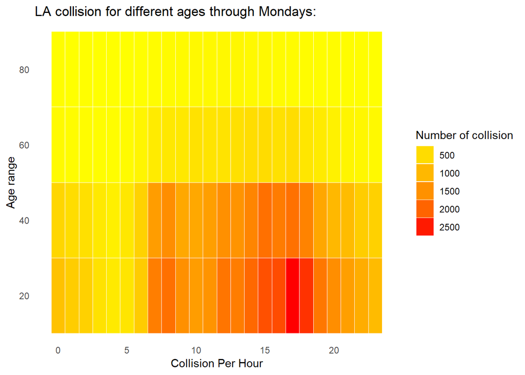

```r
age_count<-collision %>% group_by(time,age_range,weekday) %>% count()
col1 = "#d8e1cf"
col2 = "#438484"


ggplot(age_count[age_count$weekday=='Mon',], aes(time,age_range)) + geom_tile(aes(fill = n),colour = "white") +
  scale_fill_gradient(low = "yellow", high = "red") +
  guides(fill=guide_legend(title="Number of collision")) +
  theme_bw() + theme_minimal() +
  labs(title = "LA collision for different ages through Mondays: ",
       x = "Collision Per Hour", y = "Age range") +
  theme(panel.grid.major = element_blank(), panel.grid.minor = element_blank())
```

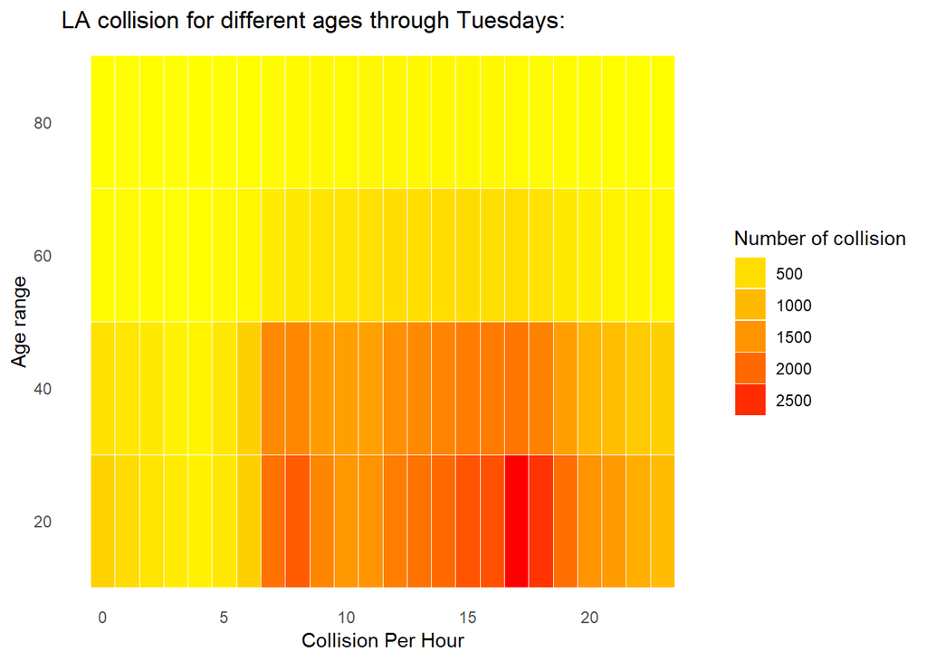

```r
ggplot(age_count[age_count$weekday=='Tue',], aes(time,age_range)) + geom_tile(aes(fill = n),colour = "white") +
  scale_fill_gradient(low = "yellow", high = "red") +
  guides(fill=guide_legend(title="Number of collision")) +
  theme_bw() + theme_minimal() +
  labs(title = "LA collision for different ages through Tuesdays: ",
       x = "Collision Per Hour", y = "Age range") +
  theme(panel.grid.major = element_blank(), panel.grid.minor = element_blank())
```

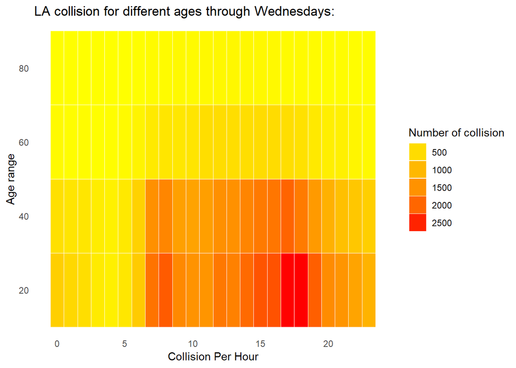

```r
ggplot(age_count[age_count$weekday=='Wed',], aes(time,age_range)) + geom_tile(aes(fill = n),colour = "white") +
  scale_fill_gradient(low = "yellow", high = "red") +
  guides(fill=guide_legend(title="Number of collision")) +
  theme_bw() + theme_minimal() +
  labs(title = "LA collision for different ages through Wednesdays: ",
       x = "Collision Per Hour", y = "Age range") +
  theme(panel.grid.major = element_blank(), panel.grid.minor = element_blank())
```

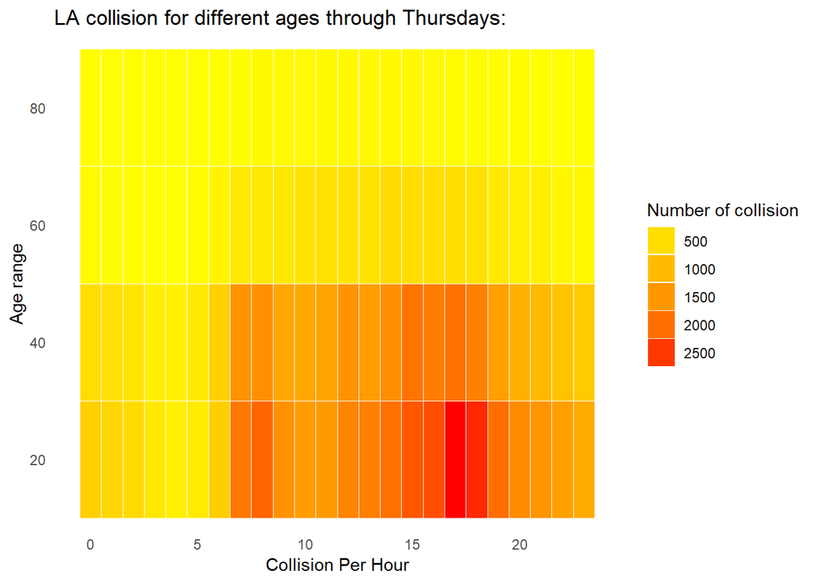

```r
ggplot(age_count[age_count$weekday=='Thu',], aes(time,age_range)) + geom_tile(aes(fill = n),colour = "white") +
  scale_fill_gradient(low = "yellow", high = "red") +
  guides(fill=guide_legend(title="Number of collision")) +
  theme_bw() + theme_minimal() +
  labs(title = "LA collision for different ages through Thursdays: ",
       x = "Collision Per Hour", y = "Age range") +
  theme(panel.grid.major = element_blank(), panel.grid.minor = element_blank())
```

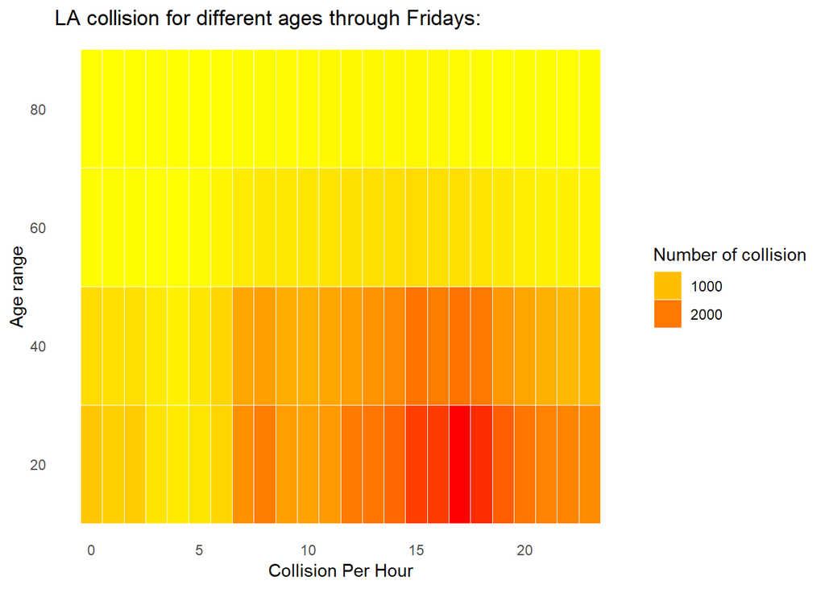

```r
ggplot(age_count[age_count$weekday=='Fri',], aes(time,age_range)) + geom_tile(aes(fill = n),colour = "white") +
  scale_fill_gradient(low = "yellow", high = "red") +
  guides(fill=guide_legend(title="Number of collision")) +
  theme_bw() + theme_minimal() +
  labs(title = "LA collision for different ages through Fridays: ",
       x = "Collision Per Hour", y = "Age range") +
  theme(panel.grid.major = element_blank(), panel.grid.minor = element_blank())
```

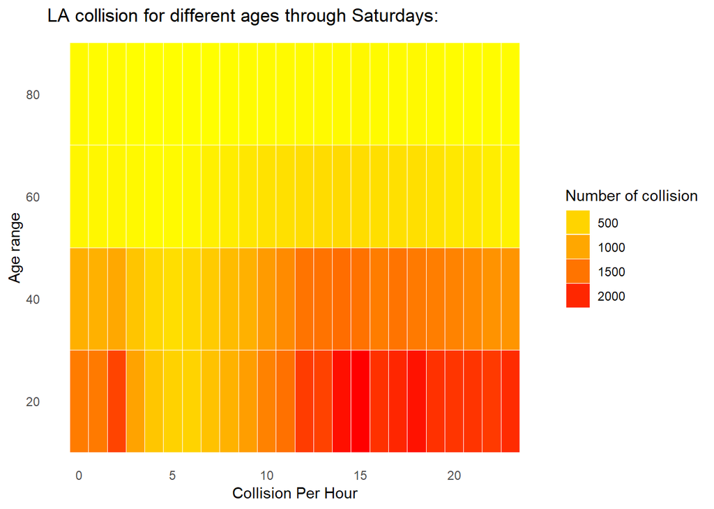

```r
ggplot(age_count[age_count$weekday=='Sat',], aes(time,age_range)) + geom_tile(aes(fill = n),colour = "white") +
  scale_fill_gradient(low = "yellow", high = "red") +
  guides(fill=guide_legend(title="Number of collision")) +
  theme_bw() + theme_minimal() +
  labs(title = "LA collision for different ages through Saturdays: ",
       x = "Collision Per Hour", y = "Age range") +
  theme(panel.grid.major = element_blank(), panel.grid.minor = element_blank())
```

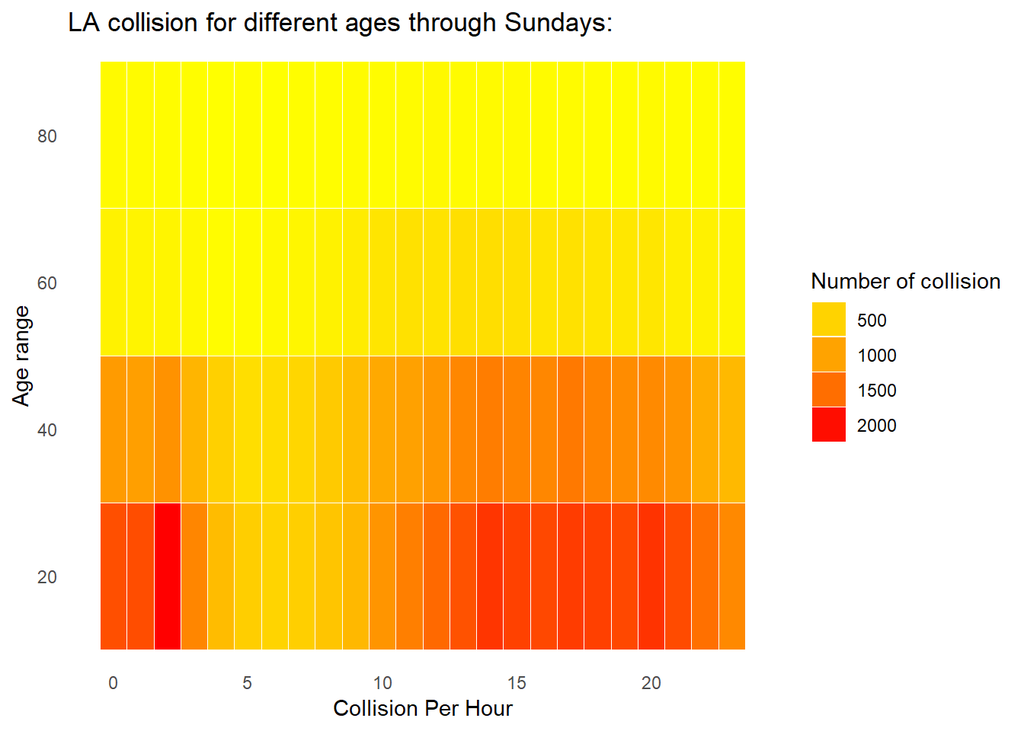

```r
ggplot(age_count[age_count$weekday=='Sun',], aes(time,age_range)) + geom_tile(aes(fill = n),colour = "white") +
  scale_fill_gradient(low = "yellow", high = "red") +
  guides(fill=guide_legend(title="Number of collision")) +
  theme_bw() + theme_minimal() +
  labs(title = "LA collision for different ages through Sundays: ",
       x = "Collision Per Hour", y = "Age range") +
  theme(panel.grid.major = element_blank(), panel.grid.minor = element_blank())
```

```r
year_wise_count<-collision %>% group_by(year) %>% count()
year_wise_count
```

| year | n |
| --- | --- |
| 2010 | 45087 |
| 2011 | 45276 |
| 2012 | 45400 |
| 2013 | 45033 |
| 2014 | 46950 |
| 2015 | 52485 |
| 2016 | 56527 |
| 2017 | 57722 |
| 2018 | 57119 |
| 2019 | 36785 |